# Resolución Actividad 3 máster Bioinformática UNIR (2025)

Laura Yera Fernandez, Edurne García Vidal, Sergio Gil Peña, Ander López Imas

2025-06-10

# Algoritmos e Inteligencia Artificial: Actividad 3 grupal

## Librerías

```r
rm(list=ls())
library(tidyverse)
library(caret)
library(ggplot2)
library(stats)
library(Rtsne)
library(uwot)
library(glmnet)
library(factoextra)
library(cluster)
library(kernlab)
library(randomForest)
```

## Lectura y procesamiento de los datos

```r
setwd("G:/PERSONAL/Edurne/MasterBioInformatica_UNIR/Asignaturas/1rSemestre_AlgoritmoseInteligenciaArtificial/Actividad3")

genes.raw <- readLines("column_names.txt")

labels.raw <- read.csv('classes.csv', header = FALSE, sep = ";")
colnames(labels.raw) <- c("X","Class")
labels.raw$Class <- as.factor(labels.raw$Class)

data.raw <- read.csv('gene_expression.csv', header = FALSE, sep = ";")
colnames(data.raw) <- genes.raw
#asumimos que la lista de genes corresponde ordenadamente a las columnas de los datos de la expresión de genes, si no quisieramos relacionarlo deberiamos escribir este código colnames(data.raw) <- paste0("gene_", c(1:500))
rownames(data.raw) <- labels.raw$X
data.raw$Class <- labels.raw$Class
```

## Sanity check data e imputación de datos faltantes

```r
anyNA(data.raw)
```

```
## [1] FALSE
```

```r
#Vemos que no hay datos NA o NaN (Not available o Not a number) en la data, por
#lo que no nos hará falta imputar.

any(data.raw[ , -ncol(data.raw)] == 0)
```

```
## [1] TRUE
```

```r
zero_counts <- colSums(data.raw[ , -ncol(data.raw)] == 0)
zero_counts
```

```
##     DUOXA1       INTU       UMOD     STXBP4       PARN    TSC22D4      TTLL5
##          0          0          0          0          0          0          0
##     ZNF880     SPATA1      PLIN3     AKAP12      USP48       UBR4     CCDC92
##          0          0        497          0          0          0          0
##     ATP5MK      VEGFD      DDX42    CASKIN2     OR10P1       SHC1  KRTAP12-2
##          0          0          0         49          0          0          1
##      CCER2      SAXO1     LEFTY1      STAG3    BLOC1S3    SEC23IP      KAT14
##         92         86          0          0          0          0          0
##       FHL2    CXorf38      MFAP2       MTA2       EMC8      ADCY2      PHKG2
##          0          0          0          0          0        410          0
##     RNF216       CNN2       SMC5        CBL    CT47A10      LRFN4     ZNF763
##          2          0          0          0          0          0          0
##       PIGU       ATE1       LGI4     POU6F1      PDE3A     LRRC4B    KBTBD13
##          0          0          0          0          0        308        600
##      ABHD8      COX7B     CYB561      H3C12     DCAF11      BNIP1      GRAPL
##          0          0          0          0          0          0         60
##     NIBAN2       MND1     ELOVL4       CDK6      BBOX1       PEPD    SLC6A18
##          0          0          0          3        313          0        230
##      RPL19   APOBEC3A      ACSM3    TBC1D26     PRDM15      PANK3       LSM3
##          4          1          0        413        134        102         21
##  TMPRSS11B     DNAJB5     COMMD3       GFI1     HOXB13      OPRM1      QRFPR
##          0          0          0        112         14          0          0
##      HDAC7        PGD   PRAMEF20       HPS1      WDR76     OR2A12     CAPN10
##         33         18          2        700          0          0          0
##      ACKR4     SLC7A3      P2RX1      MOB3C      SGIP1       LMLN      FRMD7
##        703        658        145          0          2        535          1
##      MRPS7   SHISAL2B       BMI1   C13orf46     XNDC1N      CIART     OR51F1
##        673        736          0          0          0        304        359
##    UGT2B17     CERCAM      AS3MT     HIVEP2       MXD1       SAT1      CBLL2
##          0          0          0          0          0          0          1
##    TMEM50A      RAB32      PCGF5      SPCS2       AQP4     IFNA17      OR8H2
##        229          2        558        320          1          0        257
##       NASP       MIB1       DPH6     MRPL41    SPDYE15      FOXJ3       ASPA
##          2          8          0          0        264          0          0
##     RNF223     CYP2A6      OR5W2      LYPD6     ATP5PD    SLC35G1       ABL1
##        231          0          0          0         31        333        131
##    SPDYE13     ADGRG2        DPT      TUBB3     RALBP1      STUB1      KRT77
##          0          0          0          0          0          0          0
##      VWC2L      MIER3   C11orf68       GPN2       FMO5    CCNYL1B      LRRN4
##          0        801          0        166         96          0          0
```

[output cut: 89 more lines]

```
##         10          0          0          0          0          0          0
##       KLK3       IDO2       HES3    FAM133A       ARTN     DUSP29     ANKIB1
##          0          0          0          0        117          0          0
##       RIC1    EXOSC10       FTMT     NPC1L1    RAP1GAP   CRISPLD2     KCTD15
##          1         31          1          0        469          0          0
##       ENSA     ZNF425     PODNL1     PPP4R4      UBE3C     PIK3R4     WNT10B
##          0        786          0          0          7          0          0
##      DLEC1     OSBPL5       MYH2     LRRC55        MET     SMNDC1       LRP4
##          7          0          2          0          4        662          1
##      CPSF2        CFB   FRA10AC1     FIGNL1      ZNRF2        LCK       BMP3
##         87          2          2          0          0        505        115
##       NPTN      BCAR3      PVALB     PTPN11   C19orf33     GASK1A    TMEM114
##         13          0          0        235         49          4          0
##        UCN      RAB25      TTC31
##          3        791          0
```

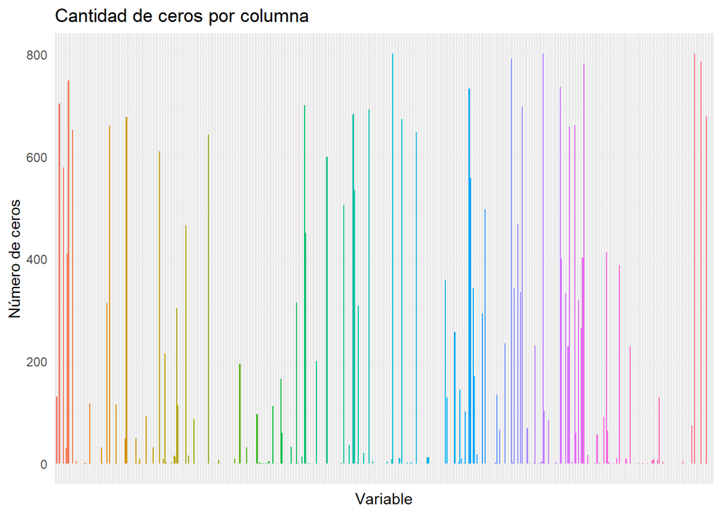

```r
zero_df <- data.frame(
  Variable = names(zero_counts),
  Zeros = as.numeric(zero_counts)
)
ggplot(zero_df, aes(x = Variable, y = Zeros, fill = Variable)) +
  geom_bar(stat = "identity") +
  labs(title = "Cantidad de ceros por columna",
       x = "Variable",
       y = "Número de ceros") +
  theme_minimal() +
  theme(legend.position = "none",
        axis.text.x = element_blank())  # Oculta la leyenda
```

```r
# Vemos que hay genes que no tienen ceros, genes que tienen algún cero y genes que
# tienen muchísimos (>600). Estos últimos casos podrían deberse o a que el gen no se
# expresa o a que hay un error de detección en la técnica. En cualquiera de los casos,
# lo mejor sería simplemente eliminar dichas variables.

# Estableceremos la norma de eliminar aquellas variables con 75% o más de ceros.
max_zeros <- 0.75*nrow(data.raw)

table(zero_counts > max_zeros)
```

```
##
## FALSE  TRUE
##   476    24
```

```r
genes_a_eliminar <- names(zero_counts[zero_counts > max_zeros])

data_filtered <- data.raw %>%
  select(-all_of(genes_a_eliminar))

# También eliminaremos todos aquellos genes que tengan el mismo valor en todas
# las observaciones (sd == 0) ya que no aportan ninguna información.

data_filtered_sd <- sapply(data_filtered[, -ncol(data_filtered)], sd)
anyNA(data_filtered_sd)
```

```
## [1] FALSE
```

```r
table(data_filtered_sd == 0)
```

```
##
## FALSE
##   476
```

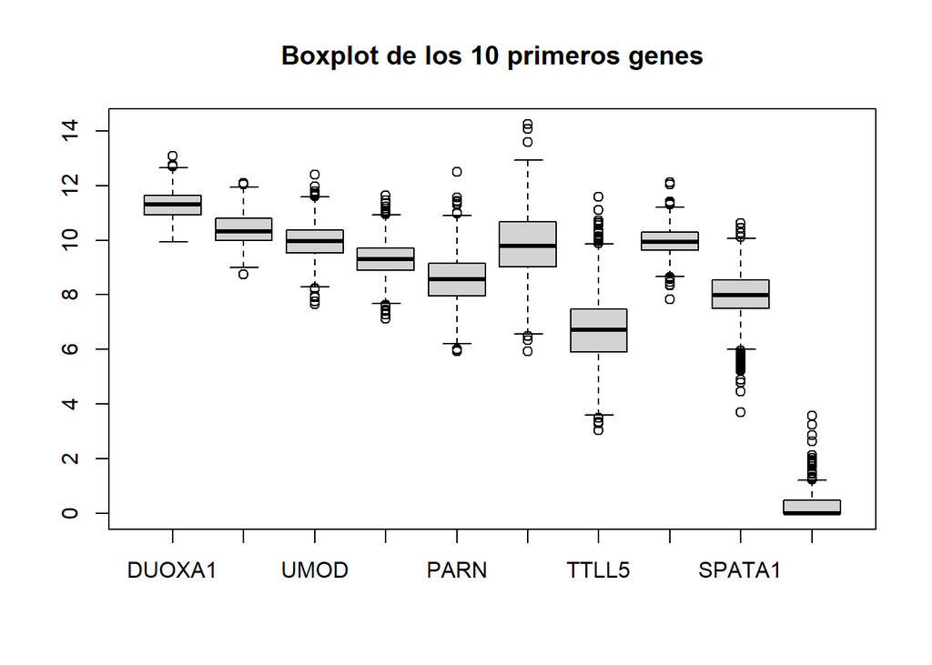

```r
# Todos son FALSE (y no hay ningun dato NA), asi que no hay ninguna variable con SD == 0.

# Podemos hacer un diagrama de cajas para variable y vemos los estadísticos y outliers
boxplot(data_filtered[, 1:10], main = "Boxplot de los 10 primeros genes")
```

```r
# Sólo mirando los primeros genes, ya vemos que se mueven en ordenes distintos,
# por lo que lo más correcto sería escalar los datos para que puedan ser comparables.
# Si decidimos hacerlo, lo haremos directamente en los métodos de aprendizaje.
```

## Implementación de métodos no supervisados

### Reducción de dimensionalidad

A partir de métodos no supervisados reducimos la dimensionalidad de los datos, que consiste en transformar el conjunto de datos que tenemos de forma que se mantenga la información más relevante y se descarte la más redundante.

Para ello, los dos métodos de reducción de dimensionalidad escogidos son: t-SNE y UMAP.

#### t-SNE

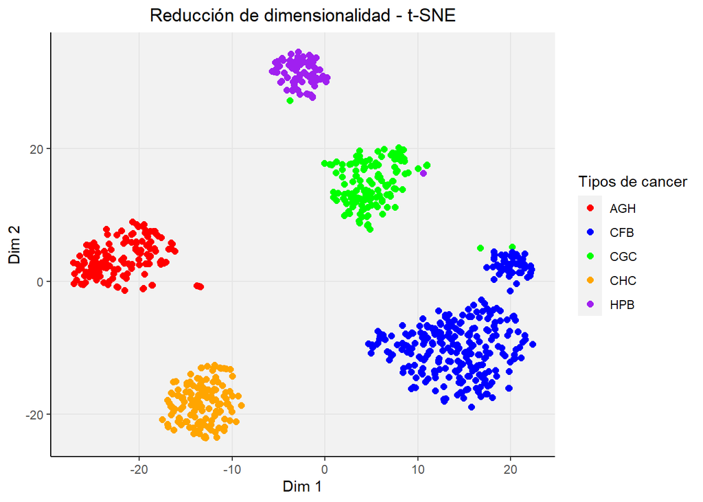

```r
# Seteamos la semilla para que sea replicable el algoritmo
set.seed(1999)

#Guardar en un dataframe los genes
df <- sapply(data_filtered[1:476], as.numeric)

tsne <- Rtsne(X = df, dims = 2)
tsne_result <- data.frame(tsne$Y)

# Graficamos
tsne_plot <- ggplot(tsne_result, aes(x = X1, y = X2, color = data_filtered$Class)) +
  geom_point(size = 2) +
  scale_color_manual(values = c("red", "blue", "green", "orange", "purple")) +
  labs(title = "Reducción de dimensionalidad - t-SNE", x = "Dim 1", y = "Dim 2", color = "Tipos de cancer") +
  theme_classic() +
  theme(panel.grid.major = element_line(color = "gray90"),
        panel.grid.minor = element_blank(),
        panel.background = element_rect(fill = "gray95"),
        plot.title=element_text(hjust=0.5))

tsne_plot
```

```r
# A partir del método no supervisado anterior (t-SNE) se ha mostrado una buena separación de los grupos, manteniendo
# bien la estructura local de los puntos cercanos entre sí. Aún así, se puede observar algún punto desviado cercano
# a un grupo distinto al que realmente pertenece. Por esta razón, decidimos probar otra técnica no lineal como es
# UMAP, que se usa cuando los datos son más complejos y que podrían ofrecer una representación distinta de la
# estructura de nuestros datos. Además, con esta otra técnica se podría reforzar los patrones observados con t-SNE.
```

#### UMAP

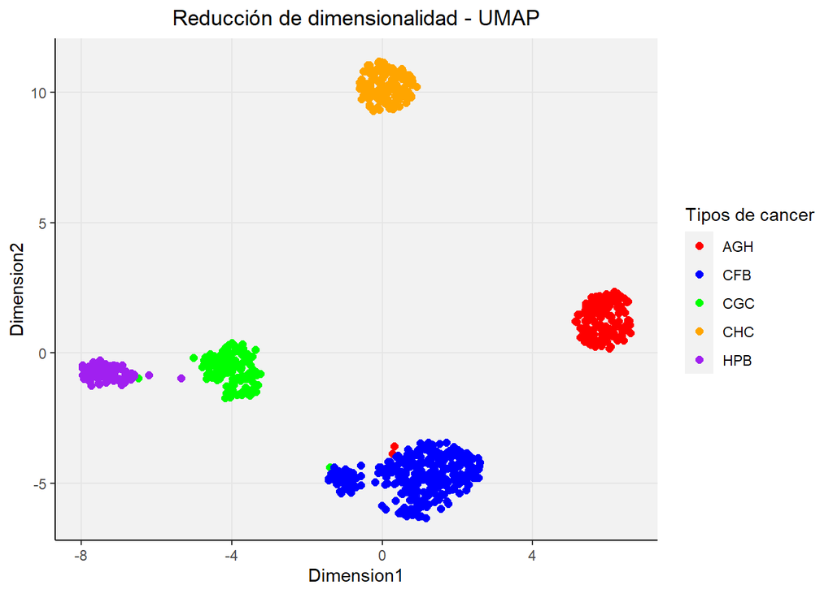

```r
# Seteamos la semilla para que sea replicable el algoritmo
set.seed(1999)

# Usamos el mismo dataframe (df) de los genes
umap.results <- umap(df,
                     n_neighbors = 0.1*nrow(df),
                     n_components = 2,
                     min_dist = 0.2,
                     local_connectivity=1,
                     ret_model = TRUE,
                     verbose = FALSE,
                     scale = FALSE)

umap.df <- data.frame(umap.results$embedding)

# Graficamos
umap_plot <- ggplot(umap.df, aes(x = X1, y = X2, color = data_filtered$Class)) +
  geom_point(size = 2) +
  scale_color_manual(values = c("red", "blue", "green", "orange", "purple")) +
  labs(title = "Reducción de dimensionalidad - UMAP", x = "Dimension1", y = "Dimension2", color = "Tipos de cancer") +
  theme_classic() +
  theme(panel.grid.major = element_line(color = "gray90"),
        panel.grid.minor = element_blank(),
        panel.background = element_rect(fill = "gray95"),
        plot.title=element_text(hjust=0.5))

umap_plot
```

```r
# UMAP es una técnica de reducción de dimensionalidad que asume que las muestras están distribuidas de manera
# uniforme en un espacio topológico y que se puede aproximar a partir de estas muestras para proyectarlas en
# un espacio de menor dimensión. Al aplicar UMAP, se genera una visualización de dos dimensiones, donde podemos
# observar claramente los 5 grupos correspondientes a los 5 tipos de cancer. Pese a ser la técnica con mayor
# costo computacional, UMAP mantiene tanto la estructura local como la global, lo que la hace más últil para
# representar datos con estructuras complejas como los que tenemos.
# A pesar de ello, seguimos viendo algún punto verde (CGC) muy cerca a otros grupos (HPB y CFB), así como algún
# punto rojo que al parecer se parece mucho al cluster de CFB.
```

### Clusterización

Con los métodos de clusterización, lo que buscamos es crear subgrupos dentro de nuestras muestras, de modo que aquellas más similares se juntaran. En esta asignatura hemos estudiado dos tipos de métodos de clusterización: jerárquicos y no jerárquicos. Probaremos uno de cada tipo.

#### Clusterización no jerárquica: método K-means

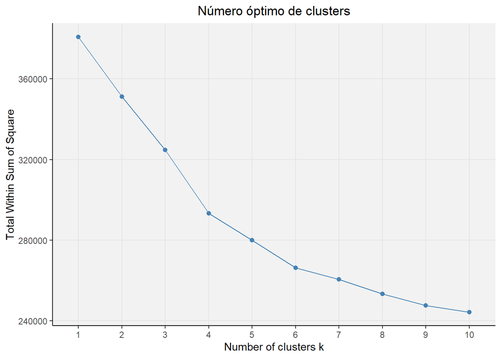

```r
# En el método K-means deberemos ajustar el número de centroides (k), para ello
# vamos primero a identificar cual es el número óptimo para nuestros datos.
# Pero antes aplicaremos un escalado a nuestros datos, ya que k-means usa distancias
# euclidianas.

df_scaled <- scale(df)

clusters_plot <- fviz_nbclust(df_scaled, kmeans, method = "wss") +
  ggtitle("Número óptimo de clusters") +
  theme_classic() +
  theme(panel.grid.major = element_line(color = "gray90"),
        panel.grid.minor = element_blank(),
        panel.background = element_rect(fill = "gray95"),
        plot.title=element_text(hjust=0.5))

clusters_plot
```

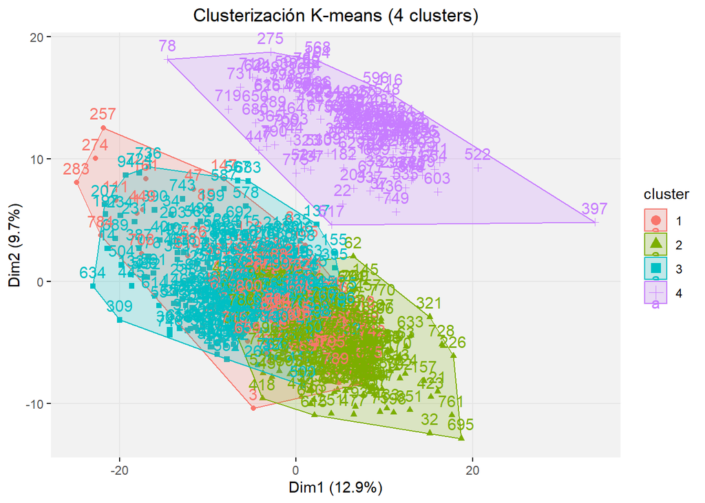

```r
# Siguiendo la regla del codo (escoger el punto a partir del cual la curva se
# allana), hemos decidido escoger k = 4 como el valor óptimo.

set.seed(1999)
kmeans.result <- kmeans(df_scaled,
                        centers = 4,
                        iter.max = 100,
                        nstart = 50)

kmeans_plot <- fviz_cluster(kmeans.result, df_scaled) +
  ggtitle("Clusterización K-means (4 clusters)") +
  theme(panel.grid.major = element_line(color = "gray90"),
        panel.grid.minor = element_blank(),
        panel.background = element_rect(fill = "gray95"),
        plot.title=element_text(hjust=0.5))

kmeans_plot
```

```r
# A pesar de escalar datos y modificar el número de veces que se reinicia el algoritmo,
# sólo podemos separar un grupo, mientras que los otros tres clusters quedan muy pegados.
# Esto puede deberse a que nuestro dataset no es especialmente pequeño, y con datos
# pequeños es cuando este método es más eficiente.
```

#### Clusterización jerárquica: DIANA (Divisive Analysis Clustering)

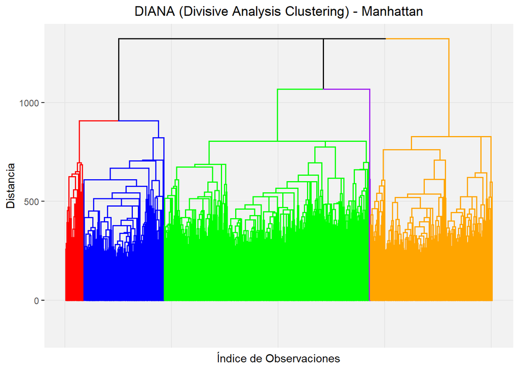

```r
# Para este método también usaremos los datos escalados (como ya lo hemos hecho
# de antemano, usaremos stand = FALSE)

diana.results.euclidean <- diana(df_scaled, stand = FALSE, metric = "euclidean")
diana.results.manhattan <- diana(df_scaled, stand = FALSE, metric = "manhattan")

# Hemos probado ambas metricas y nos ha gustado más el resultado con manhattan:
diana_plot <- fviz_dend(diana.results.manhattan, cex = 0, k = 5,
                        palette = c("red", "blue", "green", "purple", "orange"),
                        main = "DIANA (Divisive Analysis Clustering) - Manhattan",
                        xlab = "Índice de Observaciones",
                        ylab = "Distancia") +
  theme(panel.grid.major = element_line(color = "gray90"),
        panel.grid.minor = element_blank(),
        panel.background = element_rect(fill = "gray95"),
        plot.title=element_text(hjust=0.5))
diana_plot
```

```r
# Hemos decidido usar un k = 5, por si coincidia con el número de grupos de nuestra
# base de datos, pero no parece que coincidan (uno de los grupos parece que tiene solo como observaciones).
# Tal vez se debería hacer una reducción de dimensionalidad previa, o trabajar con una base de
# datos más sencilla.
```

## Implementación de métodos supervisados

En esta parte, implementaremos tres métodos supervisados distintos para poder predecir una variable objetivo a partir de unos datos de entrada. Para ello debemos dividir nuestro dataframe en dos partes: una parte del dataframe para entrenar el modelo y otra parte para testear ese modelo.

### Filtrado de variables mediante LASSO/Ridge/Elastic Net

En primer lugar, queremos ver si hay alguno de los genes de nuestra base de datos que aporte menos información y que pueda ser filtrado para que la base de datos esté más simplificada. Para ello, utilizamos modelos lineales de regularización. Hay 3 modelos:

- Modelos LASSO: da un peso nulo a las variables poco importantes
- Modelos Ridge: da un peso pequeño pero no nulo a las variables menos importantes
- Modelos Elasticnet: es un modelo intermedio entre los dos anteriores

En nuestro caso utilizamos Elasticnet, para eliminar sólo aquellos genes más irrelevantes.

```r
genes <- names(data_filtered[1:476])

# Preparamos los datos para el modelo Elasticnet
x <- as.matrix(data_filtered[, genes])
y <- factor(data_filtered$Class)

# Hiperparametro alpha (0-1 -> Elasticnet)
# family: multinomial porque tenemos 5 tipos de tumor

set.seed(1999)
Elasticnet_model <- cv.glmnet(x, y, family = "multinomial", alpha = 0.5)
selected_genes <- coef(Elasticnet_model, s = "lambda.min") # extraemos los coeficientes

selected_genes_tipos <- data.frame(
  "AGH" = as.vector(selected_genes$AGH),
  "CFB" = as.vector(selected_genes$CFB),
  "CGC" = as.vector(selected_genes$CGC),
  "CHC" = as.vector(selected_genes$CHC),
  "HPB" = as.vector(selected_genes$HPB)
)

rownames(selected_genes_tipos) <- rownames(selected_genes$AGH)

# Eliminamos la fila "(Intercept)" porque no la necesitamos
selected_genes_tipos_no_intercept <- selected_genes_tipos[rownames(selected_genes_tipos) != "(Intercept)", ]

# Filtramos genes con al menos un coeficiente distinto de 0
genes_filtrados <- selected_genes_tipos_no_intercept[apply(selected_genes_tipos_no_intercept != 0, 1, any), ]
names <- rownames(genes_filtrados)


# Seleccionamos la variable a predecir (Class) y las variables relevantes (names)
# a partir de nuestra base de datos original filtrada (data_filtered)
data <- data_filtered %>%
  dplyr::select(Class, all_of(names))

write_csv(data, "G:/PERSONAL/Edurne/MasterBioInformatica_UNIR/Asignaturas/1rSemestre_AlgoritmoseInteligenciaArtificial/Actividad3/stata.csv")

# Dividiremos el conjunto de datos en conjuntos de entrenamiento y prueba

table(data$Class)
```

```
##
## AGH CFB CGC CHC HPB
## 146 300 141 136  78
```

```r
set.seed(1999)
trainIndex <- createDataPartition(data$Class, p = 0.8, list = FALSE)
data$Class <- as.factor(data$Class) #importante para la prediccion (no regresion)
trainData <- data[trainIndex,]
testData <- data[-trainIndex,]
```

### Modelo supervisado K-Nearest Neightbors (KNN)

En primer lugar escogemos el modelo K-Nearest Neighbors como primer modelo supervisado porque es un algoritmo bastante intuitivo, fácil de entender y aplicar. Este modelo, clasifica una variable en función de la mayoría de sus vecinos más cercanos, esto lo hace adecuado para este conjunto de datos que tenemos, puesto que tenemos un conjunto de expresión de genes que deben clasificarse en 5 tipos de tumores distintos según la expresión de esas variables.

```r
# Para el modelo k-NN utilizamos el paquete caret
# Usamos trainData para entrenar el modelo
# Metodo de cross-validation (10 folds)
# preProceso -> Escalado y centrado de los datos
# tuneLength -> Probar con un vector de vecinos de longitud 30

set.seed(1999)
knnModel <- train(Class ~ .,
                  data = trainData,
                  method = "knn",
                  trControl = trainControl(method = "cv", number = 10),
                  preProcess = c("center", "scale"),
                  tuneLength = 30)
knnModel
```

```
## k-Nearest Neighbors
##
## 642 samples
## 196 predictors
##   5 classes: 'AGH', 'CFB', 'CGC', 'CHC', 'HPB'
##
## Pre-processing: centered (196), scaled (196)
## Resampling: Cross-Validated (10 fold)
## Summary of sample sizes: 579, 576, 579, 578, 577, 578, ...
## Resampling results across tuning parameters:
##
##   k   Accuracy   Kappa
##    5  0.9968990  0.9958891
##    7  0.9968990  0.9958891
##    9  0.9968990  0.9958891
```

[output cut: 30 more lines]

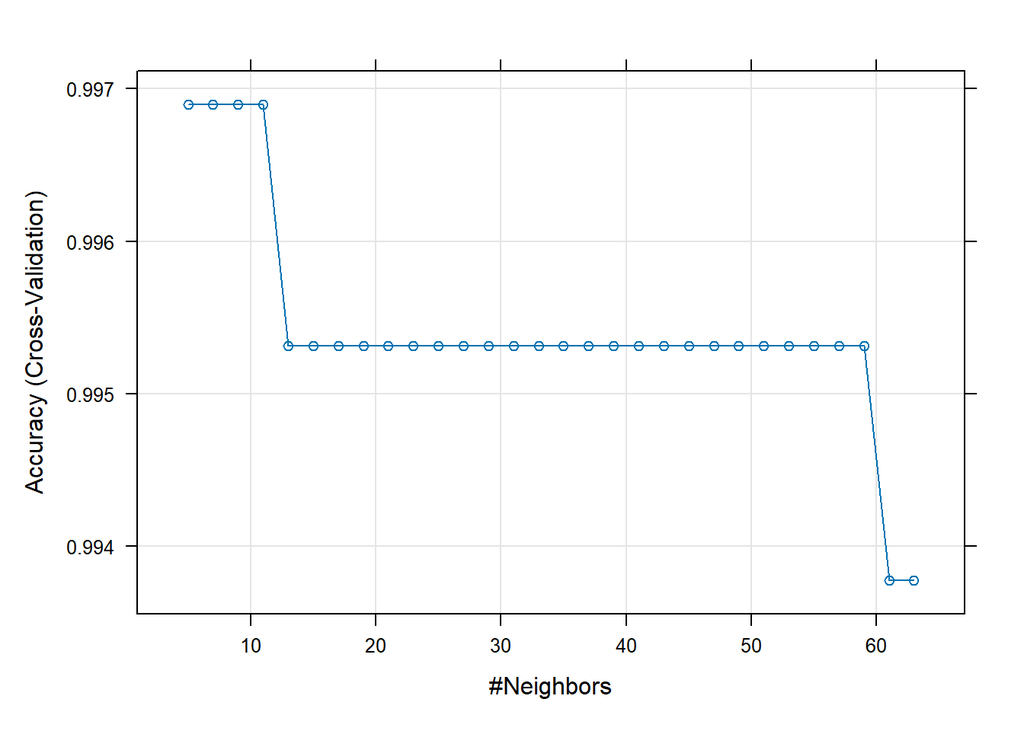

```r
plot(knnModel)
```

```r
# Realizamos predicciones en el conjunto de prueba utilizando el modelo entrenado
predictions_knn <- predict(knnModel, newdata = testData )
table(testData$Class)
```

```
##
## AGH CFB CGC CHC HPB
##  29  60  28  27  15
```

```r
table(predictions_knn)
```

```
## predictions_knn
## AGH CFB CGC CHC HPB
##  28  61  28  27  15
```

```r
# Si lo comparamos con los valores reales de la testData vemos que hay el mismo número
# de observaciones en cada clase a excepción de AGH y CFB, aunque sólo con esto no
# podemos asegurar que se han clasificado correctamente.

# Para evaluar mejor el modelo calcularemos la matriz de confusión:
cnMatrix_knn <- confusionMatrix(predictions_knn, testData$Class)
cnMatrix_knn
```

```
## Confusion Matrix and Statistics
##
##           Reference
## Prediction AGH CFB CGC CHC HPB
##        AGH  28   0   0   0   0
##        CFB   1  60   0   0   0
##        CGC   0   0  28   0   0
##        CHC   0   0   0  27   0
##        HPB   0   0   0   0  15
##
## Overall Statistics
##
##                Accuracy : 0.9937
##                  95% CI : (0.9655, 0.9998)
##     No Information Rate : 0.3774
##     P-Value [Acc > NIR] : < 2.2e-16
##
##                   Kappa : 0.9917
##
##  Mcnemar's Test P-Value : NA
##
## Statistics by Class:
##
##                      Class: AGH Class: CFB Class: CGC Class: CHC Class: HPB
## Sensitivity              0.9655     1.0000     1.0000     1.0000    1.00000
## Specificity              1.0000     0.9899     1.0000     1.0000    1.00000
## Pos Pred Value           1.0000     0.9836     1.0000     1.0000    1.00000
## Neg Pred Value           0.9924     1.0000     1.0000     1.0000    1.00000
## Prevalence               0.1824     0.3774     0.1761     0.1698    0.09434
## Detection Rate           0.1761     0.3774     0.1761     0.1698    0.09434
## Detection Prevalence     0.1761     0.3836     0.1761     0.1698    0.09434
## Balanced Accuracy        0.9828     0.9949     1.0000     1.0000    1.00000
```

```r
# Haremos una tabla que nos enseñe diferentes métricas de evaluación de nuestro modelo:
metrics_knn <- data.frame(
  "Precision" = cnMatrix_knn$byClass[, "Pos Pred Value"],
  "Sensibilidad" = cnMatrix_knn$byClass[, "Sensitivity"],
  "Especificidad" = cnMatrix_knn$byClass[, "Specificity"],
  "Score_F1" = cnMatrix_knn$byClass[, "F1"]
)
metrics_knn
```

```
##            Precision Sensibilidad Especificidad  Score_F1
## Class: AGH 1.0000000    0.9655172      1.000000 0.9824561
## Class: CFB 0.9836066    1.0000000      0.989899 0.9917355
## Class: CGC 1.0000000    1.0000000      1.000000 1.0000000
## Class: CHC 1.0000000    1.0000000      1.000000 1.0000000
## Class: HPB 1.0000000    1.0000000      1.000000 1.0000000
```

Observamos que el modelo de kNN ha clasificado correctamente a los pacientes de nuestro testData en un 99,37% de los casos (accuracy). De hecho, sólo ha fallado en un paciente que ha clasificado como CFB, siendo realmente AGH.

Además, los parámetros de especificidad y sensibilidad para las diferentes clases son perfectos (1 en tanto por 1) en todas las clases menos para CFB y AGH, debido al paciente mal clasificado, aunque aún así siguen teniendo valores superiores al 96%. La precisión (o valor predictivo positivo) es del 100% para todos menos para CFB (98.36%) debido al paciente mal clasificado. Y en cuanto al valor F1, que describe de forma global el rendimiento para cada clase vemos que es también del 100% para todos excepto AGH y CFB, aunque siguen teniendo valores muy altos (98.24% y 99.17%, respectivamente).

Viendo que las clasificaciones han sido practicamente perfectas, podríamos sospechar de over-fitting, por lo que compararemos con otros modelos más complejos.

### Modelo supervisado SMV (Support Vector Machine) tipo kernel radial

Usaremos el método SMV de tipo kernel radial, y controlaremos la C para evitar un over-fitting (si la C es muy grande).

```r
set.seed(1999)
svmModelKernel <- train(Class ~.,
                        data = trainData,
                        method = "svmRadial",
                        trControl = trainControl(method = "cv", number = 10, classProbs = TRUE),
                        preProcess = c("center", "scale"),
                        tuneLength = 15
                        )
svmModelKernel
```

```
## Support Vector Machines with Radial Basis Function Kernel
##
## 642 samples
## 196 predictors
##   5 classes: 'AGH', 'CFB', 'CGC', 'CHC', 'HPB'
##
## Pre-processing: centered (196), scaled (196)
## Resampling: Cross-Validated (10 fold)
## Summary of sample sizes: 579, 576, 579, 578, 577, 578, ...
## Resampling results across tuning parameters:
##
##   C        Accuracy   Kappa
##      0.25  0.8505979  0.8016755
##      0.50  0.8537236  0.8059336
##      1.00  0.8756032  0.8350512
##      2.00  0.8958233  0.8618872
##      4.00  0.8927456  0.8578348
##      8.00  0.8943810  0.8601362
##     16.00  0.8943570  0.8600241
##     32.00  0.8912312  0.8559309
##     64.00  0.8928185  0.8580616
##    128.00  0.8897394  0.8540820
##    256.00  0.8881295  0.8518353
##    512.00  0.8913033  0.8559888
##   1024.00  0.8912072  0.8559503
##   2048.00  0.8927945  0.8579559
##   4096.00  0.8927945  0.8579231
##
## Tuning parameter 'sigma' was held constant at a value of 0.003050714
## Accuracy was used to select the optimal model using the largest value.
## The final values used for the model were sigma = 0.003050714 and C = 2.
```

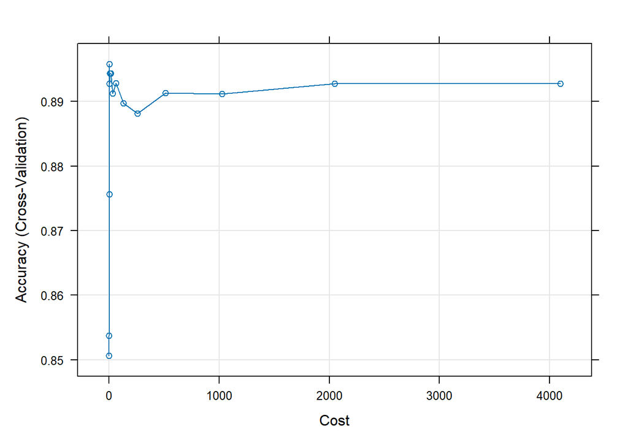

```r
plot(svmModelKernel)
```

Para este modelo se ha utilizado la misma trainData, con 10 particiones diferentes y el mejor rendimiento se ha obtenido en C=2, obteniendo una accuracy de 0.8958233, esto nos indica que el modelo es bueno para predecir el tipo de tumor, aunque la accuracy es peor que la del kNN. No obstante, esto podría deberse a que el anterior introducía cierto over-fitting. En el gráfico podemos observar que la accuracy tiene un pico global cuando la c está alrededor de 2, con c menores la accuracy baja muchísimo, y con c mayores tiene valores ligeramente inferiores pero se mantienen bastante estables (no obstante, como una C alta puede inducir a over-fitting, es mejor quedarnos con una C baja).

```r
# Realizamos las predicciones:
predictions_svmRadial <- predict(svmModelKernel, newdata = testData )
table(testData$Class)
```

```
##
## AGH CFB CGC CHC HPB
##  29  60  28  27  15
```

```r
table(predictions_svmRadial)
```

```
## predictions_svmRadial
## AGH CFB CGC CHC HPB
##  29  60  42  13  15
```

```r
# Observamos que aunque AGH, CFB y HPB tienen el mismo número de pacientes entre
# los datos reales y los predichos, hay un gran número de observaciones que parecen
# haberse movido de CHC a CGC.

# Evaluar la precisión del modelo utilizando la matriz de confusión
cnMatrix_svmRadial <- confusionMatrix(predictions_svmRadial, testData$Class)
cnMatrix_svmRadial
```

```
## Confusion Matrix and Statistics
##
##           Reference
## Prediction AGH CFB CGC CHC HPB
##        AGH  29   0   0   0   0
##        CFB   0  60   0   0   0
##        CGC   0   0  28  14   0
##        CHC   0   0   0  13   0
##        HPB   0   0   0   0  15
##
## Overall Statistics
##
##                Accuracy : 0.9119
##                  95% CI : (0.8567, 0.951)
##     No Information Rate : 0.3774
##     P-Value [Acc > NIR] : < 2.2e-16
##
##                   Kappa : 0.8834
##
##  Mcnemar's Test P-Value : NA
##
## Statistics by Class:
##
##                      Class: AGH Class: CFB Class: CGC Class: CHC Class: HPB
## Sensitivity              1.0000     1.0000     1.0000    0.48148    1.00000
## Specificity              1.0000     1.0000     0.8931    1.00000    1.00000
## Pos Pred Value           1.0000     1.0000     0.6667    1.00000    1.00000
## Neg Pred Value           1.0000     1.0000     1.0000    0.90411    1.00000
## Prevalence               0.1824     0.3774     0.1761    0.16981    0.09434
## Detection Rate           0.1824     0.3774     0.1761    0.08176    0.09434
## Detection Prevalence     0.1824     0.3774     0.2642    0.08176    0.09434
## Balanced Accuracy        1.0000     1.0000     0.9466    0.74074    1.00000
```

```r
# Haremos una tabla que nos enseñe diferentes métricas de evaluación de nuestro modelo:
metrics_svmRadial <- data.frame(
  "Precision" = cnMatrix_svmRadial$byClass[, "Pos Pred Value"],
  "Sensibilidad" = cnMatrix_svmRadial$byClass[, "Sensitivity"],
  "Especificidad" = cnMatrix_svmRadial$byClass[, "Specificity"],
  "Score_F1" = cnMatrix_svmRadial$byClass[, "F1"]
)
metrics_svmRadial
```

```
##            Precision Sensibilidad Especificidad Score_F1
## Class: AGH 1.0000000    1.0000000     1.0000000     1.00
## Class: CFB 1.0000000    1.0000000     1.0000000     1.00
## Class: CGC 0.6666667    1.0000000     0.8931298     0.80
## Class: CHC 1.0000000    0.4814815     1.0000000     0.65
## Class: HPB 1.0000000    1.0000000     1.0000000     1.00
```

### Modelo Random Forest

Ahora usaremos un modelo ensemble que combine varios árboles de decisión, para intentar tener un buen modelo y que a la vez se reduzca el riesgo de over-fitting que tal vez podría estar sucediendo en el kNN.

```r
# Usaremos settings similares al método anterior, usand trainData como datos de
# entrenamiento y una cross-validation con 10 particiones. De la misma forma,
# escalaremos y centraremos los datos antes de aplicar el método.

set.seed(1999)
rfmodel <- train(Class ~ .,
                  data = trainData,
                  method = "rf",
                  trControl = trainControl(method = "cv", number = 10),
                  preProcess = c("center", "scale"),
                  tuneLength = 10)

rfmodel
```

```
## Random Forest
##
## 642 samples
## 196 predictors
##   5 classes: 'AGH', 'CFB', 'CGC', 'CHC', 'HPB'
##
## Pre-processing: centered (196), scaled (196)
## Resampling: Cross-Validated (10 fold)
## Summary of sample sizes: 579, 576, 579, 578, 577, 578, ...
## Resampling results across tuning parameters:
##
##   mtry  Accuracy   Kappa
##     2   0.9891579  0.9856058
##    23   0.9906475  0.9876067
##    45   0.9859592  0.9813637
##    66   0.9860081  0.9814451
##    88   0.9828583  0.9772451
##   109   0.9828583  0.9772451
##   131   0.9828583  0.9772451
##   152   0.9828583  0.9772451
##   174   0.9797806  0.9731846
##   196   0.9798054  0.9732536
##
## Accuracy was used to select the optimal model using the largest value.
## The final value used for the model was mtry = 23.
```

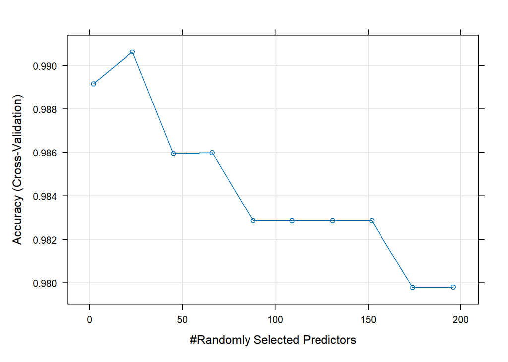

```r
plot(rfmodel)
```

Usando este método, el algoritmo ha decido que el mejor parámetro es mtry = 23, con una accuracy resultante de 0.9906 y una kappa de 0.9876. Si observamos el gráfico, vemos que al principio, la accuracy va aumentando con el mtry hasta llegar al máximo en 23, y a partir de allí aumentar el mtry sólo disminuye o estabiliza la accuracy (aunque el valor más bajo observado en la gráfica es aún de 0.98).

```r
# Ahora haremos las predicciones con este modelo
predictions_rf <- predict(rfmodel, newdata = testData )
table(predictions_rf)
```

```
## predictions_rf
## AGH CFB CGC CHC HPB
##  28  61  28  27  15
```

```r
table(testData$Class)
```

```
##
## AGH CFB CGC CHC HPB
##  29  60  28  27  15
```

```r
# En este caso vemos los grupos AGH y CFB parecen haber intercambiado una observación,
# mientras que el resto de grupos se mantiene igual.

# Para evaluar mejor modelo calcularemos la matriz de confusión:
cnMatrix_rf <- confusionMatrix(predictions_rf, testData$Class)
cnMatrix_rf
```

```
## Confusion Matrix and Statistics
##
##           Reference
## Prediction AGH CFB CGC CHC HPB
##        AGH  28   0   0   0   0
##        CFB   1  60   0   0   0
##        CGC   0   0  28   0   0
##        CHC   0   0   0  27   0
##        HPB   0   0   0   0  15
##
## Overall Statistics
##
##                Accuracy : 0.9937
##                  95% CI : (0.9655, 0.9998)
##     No Information Rate : 0.3774
##     P-Value [Acc > NIR] : < 2.2e-16
##
##                   Kappa : 0.9917
##
##  Mcnemar's Test P-Value : NA
##
## Statistics by Class:
##
##                      Class: AGH Class: CFB Class: CGC Class: CHC Class: HPB
## Sensitivity              0.9655     1.0000     1.0000     1.0000    1.00000
## Specificity              1.0000     0.9899     1.0000     1.0000    1.00000
## Pos Pred Value           1.0000     0.9836     1.0000     1.0000    1.00000
## Neg Pred Value           0.9924     1.0000     1.0000     1.0000    1.00000
## Prevalence               0.1824     0.3774     0.1761     0.1698    0.09434
## Detection Rate           0.1761     0.3774     0.1761     0.1698    0.09434
## Detection Prevalence     0.1761     0.3836     0.1761     0.1698    0.09434
## Balanced Accuracy        0.9828     0.9949     1.0000     1.0000    1.00000
```

```r
# Ahora haremos la tabla de las metricas:
metrics_rf <- data.frame(
  "Precision" = cnMatrix_rf$byClass[, "Pos Pred Value"],
  "Sensibilidad" = cnMatrix_rf$byClass[, "Sensitivity"],
  "Especificidad" = cnMatrix_rf$byClass[, "Specificity"],
  "Score_F1" = cnMatrix_rf$byClass[, "F1"]
)
metrics_rf
```

```
##            Precision Sensibilidad Especificidad  Score_F1
## Class: AGH 1.0000000    0.9655172      1.000000 0.9824561
## Class: CFB 0.9836066    1.0000000      0.989899 0.9917355
## Class: CGC 1.0000000    1.0000000      1.000000 1.0000000
## Class: CHC 1.0000000    1.0000000      1.000000 1.0000000
## Class: HPB 1.0000000    1.0000000      1.000000 1.0000000
```

Observando la matrix de confusión, vemos que en el caso del Random Forest se ha predicho érroneamente un paciente AGH como CFB, y que la accuracy del modelo es de 0.9937 (valores exactos a los del modelo kNN). Con el resto de clases no se han cometido errores, y es por ello que CGC, CGC y HPB tienen métricas perfectas de precision, sensibilidad, especificidad y score F1 (como podemos ver en la tabla metrics_rf). Fijandonos en el valor F1, vemos que este método tiene un peor score para la AGH y CFB, por el paciente mal clasificado, pero siguen siendo valores muy altos (los mismos que en el modelo kNN).

### Comparativa de los modelos de aprendizaje supervisado

Ya que el valor F1 es un valor único que nos permite evaluar cada modelo por clase, vamos a juntar en una misma tabla los valores F1 y así poder comparar los distintos modelos.

```r
scores_F1 <- data.frame(
  kNN = metrics_knn$Score_F1,
  svmRadial = metrics_svmRadial$Score_F1,
  RF = metrics_rf$Score_F1
)
rownames(scores_F1) <- rownames(metrics_knn)
scores_F1
```

```
##                  kNN svmRadial        RF
## Class: AGH 0.9824561      1.00 0.9824561
## Class: CFB 0.9917355      1.00 0.9917355
## Class: CGC 1.0000000      0.80 1.0000000
## Class: CHC 1.0000000      0.65 1.0000000
## Class: HPB 1.0000000      1.00 1.0000000
```

Al comparar los tres modelos vemos que los mejores, en cuanto a score F1 por clase, serían los modelo kNN y Random Forest, ya que tienen valores perfectos para 3 de las cinco clases (y para las otras dos siguen teniendo valores elevados de 0.98 y 0.99). Teniendo en cuenta que tanto el modelo kNN como el Random Forest han salido iguales, es probable que el aprendizaje haya sido bueno y no estemos observando over-fitting. En el modelo svmRadial vemos que el F1 score de la clase CHC es muy bajo ya que, como hemos visto en la matriz de confusión del modelo, ha clasificado mal a la mitad de pacientes CHC.

## Preguntas de respuesta corta

### Pregunta 1. Procesamiento de los datos.

**¿Qué método habéis escogido para llevar a cabo la imputación de los datos? Razonad vuestra respuesta.**

La imputación de datos en el sentido de rellenar aquellos campos en los que hubiera datos NA no se ha realizado, porque no había datos NA. En cuanto al tratamiento de 0s, se explicará a continuación.

**¿Habéis llevado a cabo algún otro tipo de procesamiento? Razonad vuestra respuesta.**

A parte de buscar datos NA, buscamos aquellas variables que tuvieran 0s. En concreto, buscamos variables que tuvieran una gran cantidad de 0s (en un 75% o más de las observaciones), ya que este tipo de resultados pueden deberse a que 1) el gen no se expresa o 2) ha habido algún error en el método de cuantificación o falta de sensibilidad. En cualquier caso, este tipo de variables probablemente no van a aportar mucha información que ayude a clasificar las observaciones, por lo que se han descartado en pos de tener una base de datos lo más manejable posible. Del mismo modo, se han buscado aquellas variables que tuvieran el mismo valor en todas las observaciones (es decir, una desviación estándard == 0), porque tampoco hubieran podido aportar valor clasificatorio. No hemos encontrado ninguna variable que cumpliese ese criterio, pero de haberlo hecho, también la hubieramos eliminado.

### Pregunta 2. Métodos no supervisados.

**¿Cuál es el motivo por el cual habéis seleccionado estas técnicas de reducción de dimensionalidad?**

Hemos decidido usar t-SNE y UMAP porque ambos pueden tratar con datos no lineales, y ambos separan bien los grupos de forma visual (además, a partir de los ejemplos de clase y de la actividad 1 nos parecían los mejores métodos). También son los métodos que más parecen usarse (algunos compañeros del grupo los han visto en artículos y en sus trabajos), por lo que nos interesaba aprender a usarlos.

**¿Cuál es el motivo por el cual habéis seleccionado estas técnicas de clusterización?**

Hemos decidido usar un método jerarquico y uno no-jerárquico. Como de los no jerárquicos sólo hemos visto k-Means en clase, ese es el que hemos hecho. De los jerárquicos decidimos hacer el divisivo (DIANA), porque en teoría es menos costoso que el jerarquico algomerativo.

**En ambos casos, ¿qué aspectos positivos y negativos tienen cada una?**

*tSNE:*

Positivos: captura bien relaciones complejas, preserva localidad de datos y también aporta algo de la estructura global.

Negativos: tiene componente estocástico y por eso hay que usar seeds, se usa sobre todo para visualizar porque el rendimiento con >3 dimensiones no es el mejor. Computacionalmente costoso con grandes cantidades de datos.

*UMAP:*

Positivos: Es eficaz y versátil para reducir la dimensionalidad.

Negativos: Muy complejo debido a todos los parámetros personalizables, que a su vez impactan sobre el coste computacional. Aunque en teoría tiene componente estocástico (como t-SNE), no se observan grandes variaciones.

*k-Means:*

Positivos: Es sencillo y poco costoso computacionalmente.

Negativos: A veces es dificil encontrar la k óptima, y es sensible a outliers.

*DIANA:*

Positivos: Menos costoso computacionalmente que otros métodos jerárquicos. A diferencia de los métodos agloerativos que van juntando puntos y se quedan unidos, los métodos divisivos empiezan por un cluster y van separando, por lo que no se ven “obligados” a mantener puntos juntos; lo que los hace más flexibles que los aglomerativos.

Negativos: Sensible a outliers. Puede ser difícil encontrar el número de clústeres óptimo y elegir la métrica óptima para la clusterización (nosotros escogimos manhattan, pero no podemos asegurar que sea la mejor opción).

**En el caso de la clusterización, ¿podéis afirmar con certeza que los clústeres generados son** l**os mejores posibles? Razonad vuestra respuesta.**

En el caso del método k-Means seleccionamos el número de clusters basándonos en la regla del codo del gráfico “clusters_plot”. Podemos observar que después de 4 clusters la pendiente disminuye, por lo que tener en cuenta más clusters a partir de 4 puede no darnos información importante. Si tuvieramos que elegir otro número de clusters sería 6, ya que también se observa otra disminución de la pendiente tras ese número (en cambio, en el cluster 5 no). No obstante, no creemos que valga la pena agregar dos clusters más por el poco extra de información que puedan aportar. En resumen, creemos que en este caso los 4 clusters generados sí son los mejores.

En cambio, para la clusterización con DIANA, hemos elegido el número de clusters basándonos en el dendograma en sí. En este caso, no tenemos tan claro que los clusters sean los mejores posibles. Por un lado se ven muchas diferencias intra-cluster, y por otro hay un cluster (lila) que realmente tiene muy poca representación. Jugando con la k llegamos a ver que visualmente el dendograma quedaba más bonito si generabamos 12 clústers. No obstante, nos parecía un número demasiado elevado, por lo que decidimos dejarlo en 5 por ser el número de tipo de tumores. En resumen, en este caso no podemos afirmar que sean los mejores clústeres.

### Pregunta 3. Métodos supervisados

**¿Cuál es el motivo por el cual habéis seleccionado ambas técnicas de aprendizaje supervisado?** **¿Cuál ha dado mejores resultados a la hora de clasificar las muestras? Razonad vuestra respuesta**

Decidimos empezar con kNN por ser un método simple. No obstante, al ver sus resultados casi perfectos decidimos usar un método más complejo (SVM radial) y después un método ensemble (Random Forest) para asegurarnos de que no estuviera ocurriendo over-fitting en nuestro modelo.

De los tres métodos usados, los que han dado mejores resultados han sido el K-Nearest Neightbors y el Random Forest (clasificaron bien / mal el mismo número de pacientes, y las distintas métricas fueron idénticas). Como ya mencionamos en medio del código, ambos métodos sólo clasificaron mal 1 paciente (un CFB que realmente era AGH) por lo que las diferentes métricas evaluadas por clase (precisión, sensibilidad, especificidad) eran perfectas para el resto de clases, mientras que para AGH y CFG eran algo menores (aunque aún así casi perfectas). Decidimos hacer una tabla para comparar el score F1 de cada modelo y llegamos a la misma conclusión: kNN y RF tenían los mejores scores, con valores perfectos para CGC, CHC y HPB, y 0.98 y 0.99 para AGH y CFB, respectivamente).

**¿Habéis considerado oportuno implementar algún método de reducción de dimensionalidad** **para procesar los datos antes de implementarlos en dichas técnicas? ¿Por qué?**

Como teniamos muchas variables y no estabamos seguros de que todas ellas fuesen a aportar información para los métodos, decidimos primero hacer un Elastic Net con el propósito de eliminar aquellas no tan necesárias. Elegimos Elastic Net en vez de Ridge o Lasso porque querímos eliminar variables para simplificar el análisis, pero sin perder demasiadas. Es por ello que decidimos eliminar de los análisis supervisados posteriores todas aquellas variables que tuvieran coeficiente 0 para todas las clases de tumores.

**¿Qué aspectos positivos y negativos tienen cada una de las técnicas que habéis escogido?**

*K-Nearest Neightbors (KNN):*

Positivos: Algoritmo simple y con capacidad adaptativa a nuevos datos introducidos. La fase de entrenamiento es rápida porque no se construye un modelo per se.

Negativos: La fase de clasificación puede ser lenta si hay muchos datos. No puede manejar datos faltantes o que no tengan un preprocesamiento adecuado, y no trabaja bien con datos desequilibrados. Además la selección del mejor número de vecinos (k) a veces puede ser arbitraria.

*Support Vector Machine (SVM) de tipo kernel radial:*

Positivos: Como no se limita a hiperplanos lineales, puede separar grupos no lineales. Es eficaz con altas dimensionalidades. Se pueden controlar parámetros para prevenir over-fitting.

Negativos: Se necesita una previa normalización de los datos para mejorar el modelo. Puede ser difícil encontrar los parámetros óptimos.

*Random Forest (RF):*

Positivos: Al combinar multiples modelos, se reduce la varianza del modelo final y se mejora la precisión y el rendimiento (mejor para evitar over-fitting). Es menos sensible a outliers.

Negativos: Computacionalmente complejo. Como es el resultado de combinar varios modelos, su interpretación puede ser compleja. Aunque este tipo de modelos ayuden con el over-fitting, si los modelos base que se combinan presentan over-fitting, pueden pasárselo al modelo final.

### Pregunta 4.

**De estas cuatro opciones, ¿qué tipo de arquitectura de deep learning sería** **la más adecuada para procesar datos de expresión génica? Razonad vuestra respuesta.**

**a) Red de perceptrones (multiperceptron layers).**

**b) Redes convolucionales.**

**c) Redes recurrentes.**

**d) Redes de grafos.**

Para procesar datos de expresión génica, entendiéndolo como el tipo de datos con los que hemos estado trabajando durante esta actividad, podríamos descartar primero varias arquitecturas:

- Redes convolucionales: se usan con imágenes y vídeos, siendo capaces de reconocer patrones. Por lo que, en nuestro caso no sería adecuado.
- Redes recurrentes: se usan para datos secuenciales de tipo texto o audio, por ejemplo para autocompletar palabras que ya se han introducido antes. Tampoco aplicaría a nuestro ejemplo.
- Redes de grafos: podríamos usarlos si tuvieramos, por ejemplo, grafos con la interacción que hay entre distintos genes. Pero como no es con lo que estamos trabajando actualmente, no sería la más adecuada.

Por lo tanto, la arquitectura más adecuada en nuestro caso (teniendo una tabla típica de expresión de genes por muestra) seria la red de perceptrones, que consistiría en una capa de entrada (con tantas neuronas como genes estamos teniendo en cuenta, o menos si hemos hecho algun tipo de reducción de dimensionalidad previo), varias capas ocultas intermedias, y una capa de salida que nos permetiría clasificar a los pacientes a partir de su expresión de genes (por ejemplo, en el caso en el que hemos estado trabajando en esta actividad, la capa de salida tendría 5 categorías, los 5 tipos de tumores).